# Examples of using the HDMA BPCells object for plotting tracks

28 April, 2025

```r
# **MODIFY THIS CHUNK**
project_id  <- "HDMA-public" # determines the name of the cache folder
doc_id      <- "05-misc/02" # determines name of the subfolder of `figures` where pngs/pdfs are saved
out         <- here::here("output/", doc_id); dir.create(out, recursive = TRUE)
figout      <- here::here("figures/", doc_id, "/")
script_path <- here::here("code/utils/")
```

# 1 Overview

Here we use the BPCells objects to quickly visualize genomic tracks at different scales.

# 2 Set up

```r
# libraries
library(rtracklayer)
library(GenomicRanges)
library(glue)
library(BPCells)
library(ggseqlogo)
suppressPackageStartupMessages({
  library(tidyverse)
  library(patchwork)
  library(here)
  library(BSgenome.Hsapiens.UCSC.hg38)
})

# shared project scripts/functions
scriptPath <- here::here("code/utils")
source(paste0(scriptPath, "/track_helpers_BL.R"))
source(paste0(scriptPath, "/track_helpers_SJ.R"))
source(paste0(scriptPath, "/trackplots.R")) # BPCells trackplot helpers in dev
```

# 3 Read in the HDMA BPCells object

```r
# read global BPCells object
global_bp_obj <- readRDS(paste0(here::here("output/05-misc/01"), "/global_bp_obj.rds"))
```

## 3.1 important note about file location

If the ATAC_merged/ RNA_merged/ RNA_raw_merged/ paths containing BPCells files are moved in the file system, must re-add to BPCells object. This is because BPCells stores raw data on disk and the BPCells objects are linked to folders on disk.

```r
# global_bp_obj$frags <- open_fragments_dir("/your/new/path/to/ATAC_merged/")
# global_bp_obj$rna <- open_matrix_dir("/your/new/path/to/RNA_merged/")
# global_bp_obj$rna_raw <- open_matrix_dir("/your/new/path/to/RNA_raw_merged/")
# saveRDS(global_bp_obj, paste0(out, "/global_bp_obj.rds"))
```

# 4 Example 1: gene

plot a gene, cluster by organ, coverage tracks only this should take less than 1min

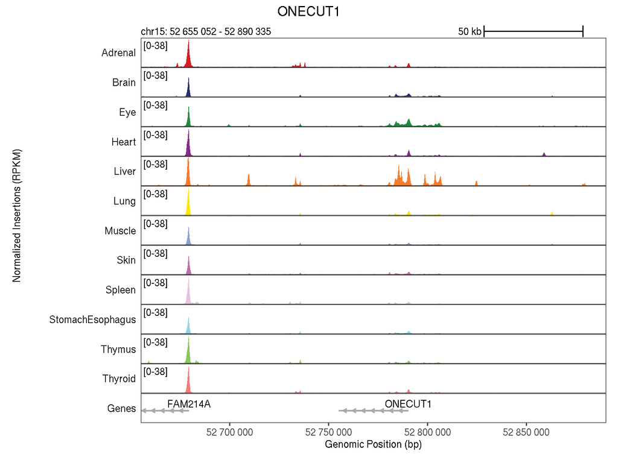

```r
p1 <- trackplot_helper_v2c(
  gene="ONECUT1",
  clusters=global_bp_obj$cell_metadata$organ,
  fragments=global_bp_obj$frags,
  cell_read_counts=global_bp_obj$cell_metadata$nFrags,
  transcripts=global_bp_obj$transcripts,
  flank=1e5
)
p1
```

# 5 Example 2: region

plot a region, cluster by organ, coverage tracks only note that the “flank” argument is not actually used when region is supplied instead of gene, if you wish to extend the window, simply give an extended region to the function

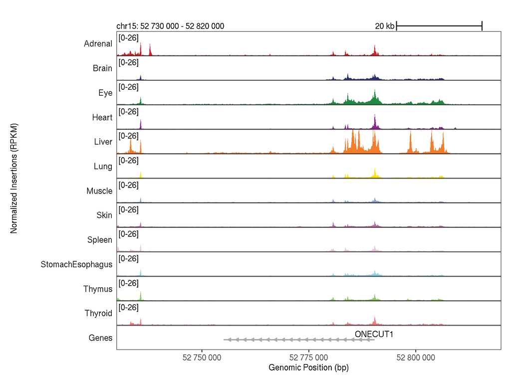

```r
p2 <- trackplot_helper_v2c(
  region="chr15:52730000-52820000",
  clusters=global_bp_obj$cell_metadata$organ,
  fragments=global_bp_obj$frags,
  cell_read_counts=global_bp_obj$cell_metadata$nFrags,
  transcripts=global_bp_obj$transcripts
)
p2
```

# 6 Example 3: decontaminated gene expression + P2G loops

plot a gene, smaller window, cluster by organ, coverage + decontXed expression + peak2gene loops

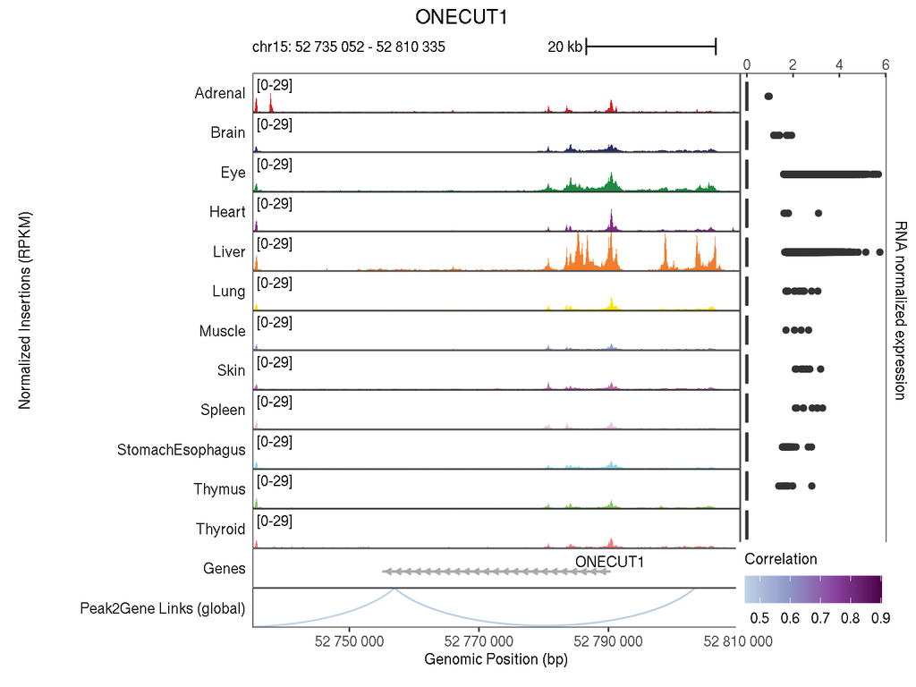

```r
p3 <- trackplot_helper_v2c(
  gene="ONECUT1",
  clusters=global_bp_obj$cell_metadata$organ,
  fragments=global_bp_obj$frags,
  cell_read_counts=global_bp_obj$cell_metadata$nFrags,
  transcripts=global_bp_obj$transcripts,
  flank=2e4,
  expression_matrix=global_bp_obj$rna,
  loops=global_bp_obj$loops_p2g$global,
  loop_color="Correlation",
  loop_label = "Peak2Gene Links (global)"
)
p3
```

# 7 Example 4: raw gene expression

plot a region, smaller window, cluster by organ, coverage + raw RNA expression

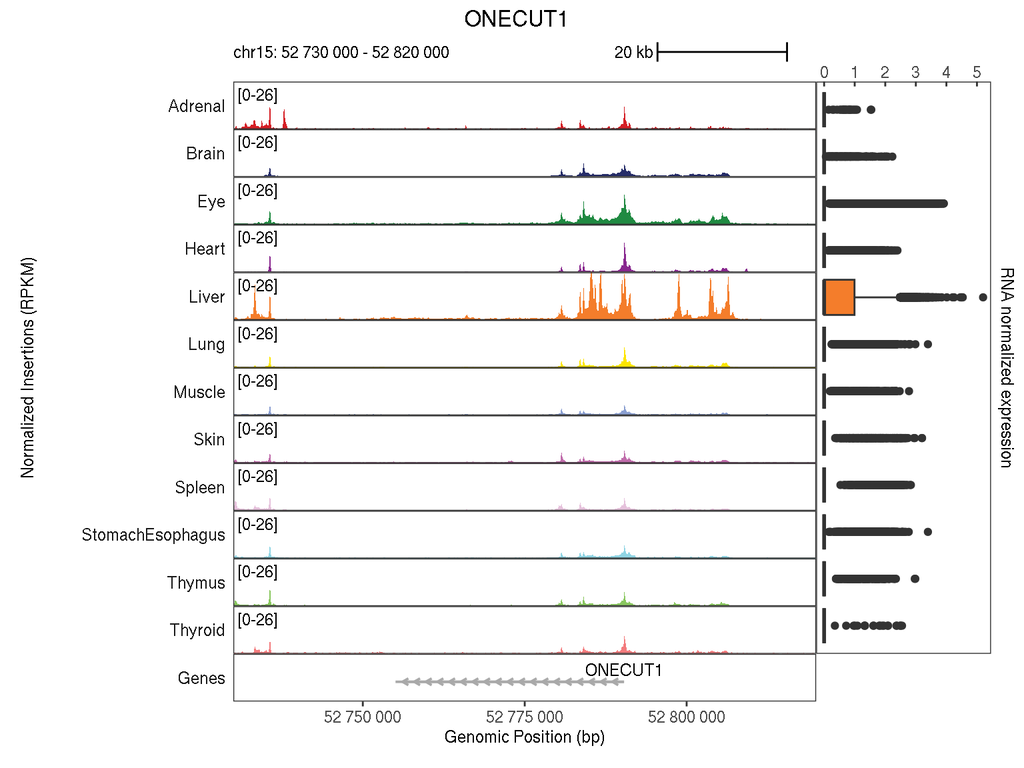

```r
p4 <- trackplot_helper_v2c(
  region="chr15:52730000-52820000",
  gene="ONECUT1",
  clusters=global_bp_obj$cell_metadata$organ,
  fragments=global_bp_obj$frags,
  cell_read_counts=global_bp_obj$cell_metadata$nFrags,
  transcripts=global_bp_obj$transcripts,
  expression_matrix=global_bp_obj$rna_raw
)
p4
```

# 8 Example 5: subsetting by organ + ABC loops

filter to eye clusters only, cluster by cell type, coverage + decontXed expression + ABC loops linked in eye clusters

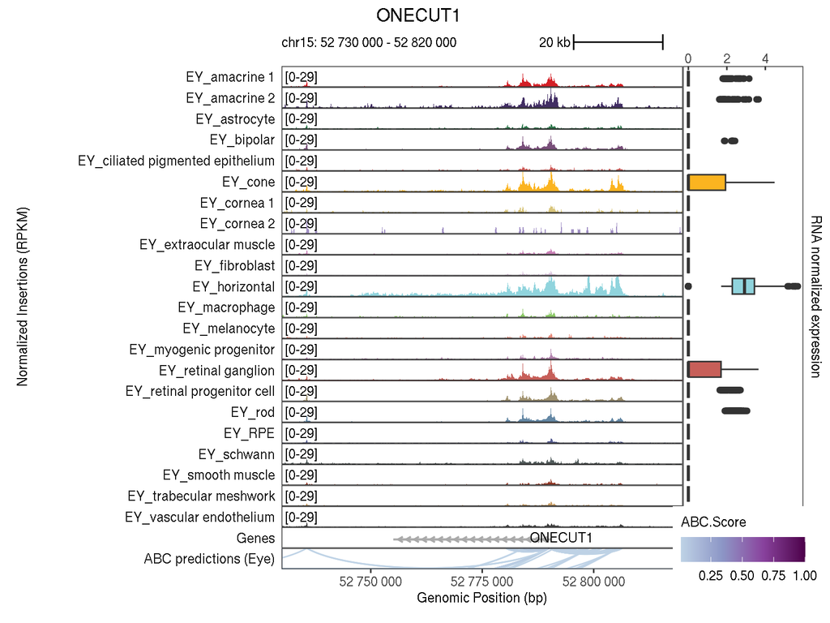

```r
submeta <- global_bp_obj$cell_metadata %>% dplyr::filter(organ=="Eye")
p5 <- trackplot_helper_v2c(
  region="chr15:52730000-52820000",
  gene="ONECUT1",
  clusters=submeta$archive_L3_clusterID,
  fragments=global_bp_obj$frags %>% select_cells(submeta$cb),
  cell_read_counts=submeta$nFrags,
  transcripts=global_bp_obj$transcripts,
  expression_matrix=global_bp_obj$rna[,submeta$cb],
  loops=global_bp_obj$loops_abc$Eye,
  loop_color="ABC.Score",
  loop_label = "ABC predictions (Eye)"
)
p5
```

# 9 Example 6: subsetting by cell type

filter to horizontal cells (eye) and hepatocytes (liver) only, cluster by cell type, coverage + decontXed expression + ABC loops linked in eye or liver clusters

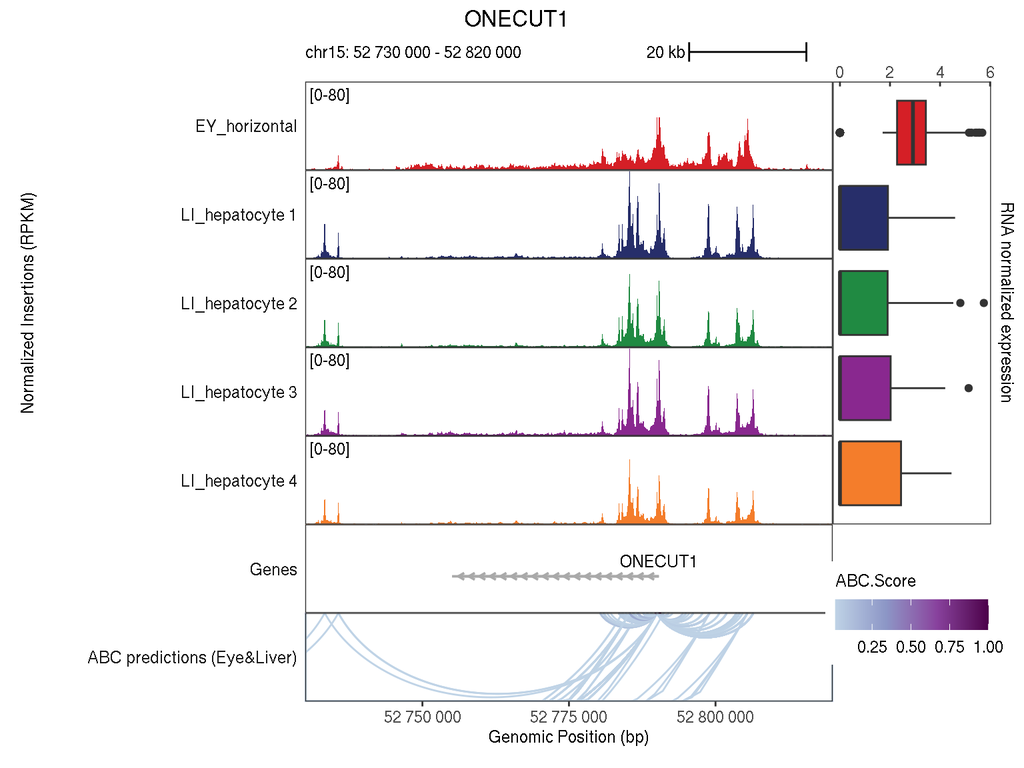

```r
submeta <- global_bp_obj$cell_metadata %>% dplyr::filter(archive_L2_clusterName %in% c("hepatocyte", "horizontal"))
p6 <- trackplot_helper_v2c(
  region="chr15:52730000-52820000",
  gene="ONECUT1",
  clusters=submeta$archive_L3_clusterID,
  fragments=global_bp_obj$frags %>% select_cells(submeta$cb),
  cell_read_counts=submeta$nFrags,
  transcripts=global_bp_obj$transcripts,
  loops=c(global_bp_obj$loops_abc$Eye, global_bp_obj$loops_abc$Liver),
  loop_color="ABC.Score",
  expression_matrix=global_bp_obj$rna[,submeta$cb],
  loop_label = "ABC predictions (Eye&Liver)"
)
p6
```

# 10 Example 7: highlight regions

plot a region, cluster by organ, coverage tracks only, add a highlight region

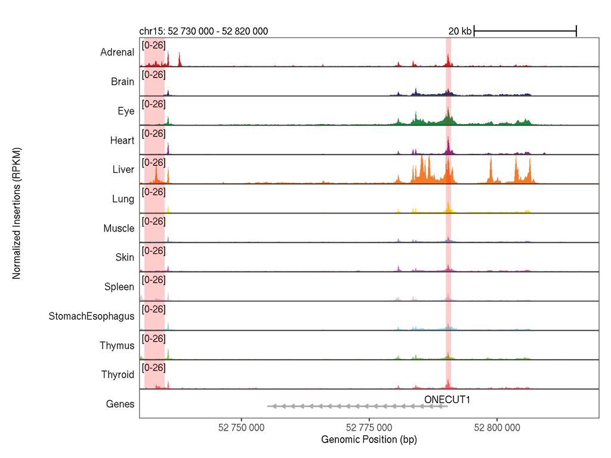

```r
p7 <- trackplot_helper_v2c(
  region="chr15:52730000-52820000",
  highlights=gr_to_highlight(GRanges(c("chr15:52731000-52735000","chr15:52790000-52791000"))),
  clusters=global_bp_obj$cell_metadata$organ,
  fragments=global_bp_obj$frags,
  cell_read_counts=global_bp_obj$cell_metadata$nFrags,
  transcripts=global_bp_obj$transcripts
)
p7
```

# 11 Example 8: peak annotations

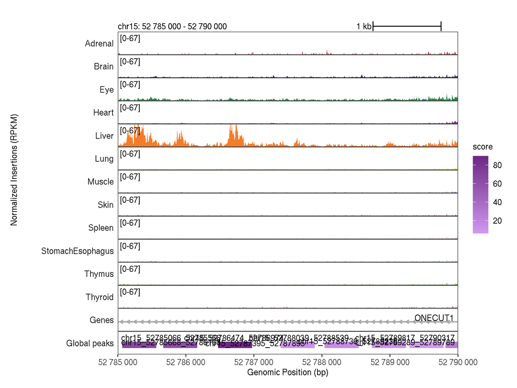

```r
p8 <- trackplot_helper_v2c(
  region="chr15:52785000-52790000",
  clusters=global_bp_obj$cell_metadata$organ,
  fragments=global_bp_obj$frags,
  cell_read_counts=global_bp_obj$cell_metadata$nFrags,
  transcripts=global_bp_obj$transcripts,
  annot=global_bp_obj$peaks$global,
  annot_color="score",
  annot_labelby="peak_name",
  annot_label="Global peaks"
)
p8
```

# 12 Example 9: motif hits annotations

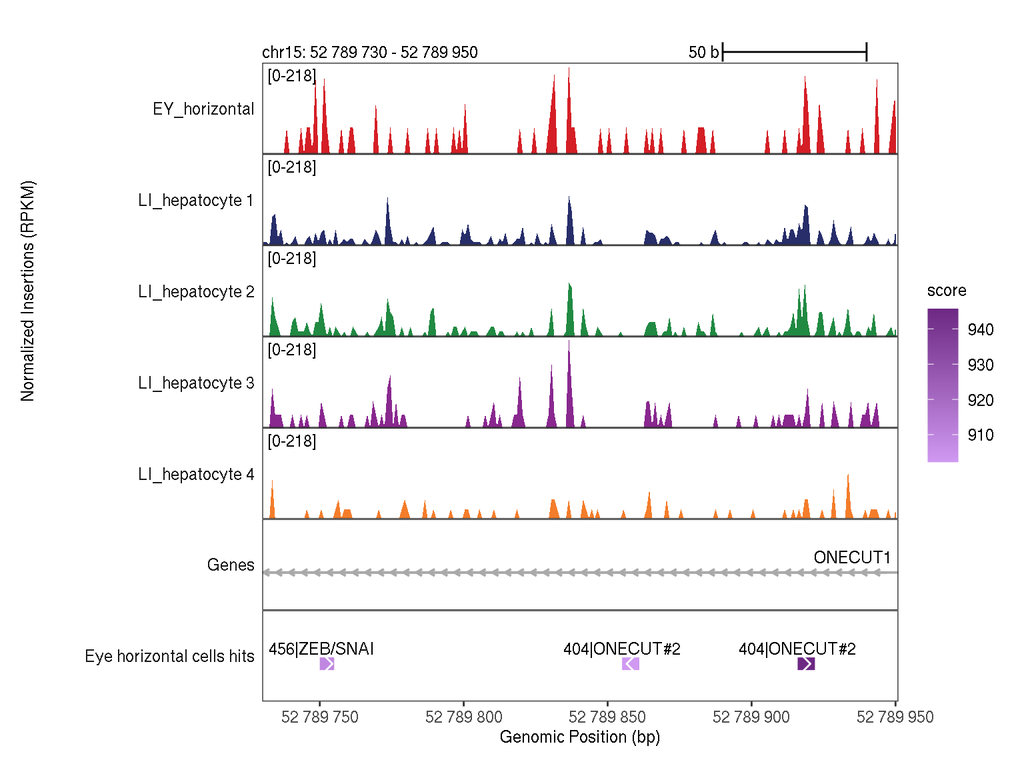

```r
submeta <- global_bp_obj$cell_metadata %>% dplyr::filter(archive_L2_clusterName %in% c("hepatocyte", "horizontal"))
p9 <- trackplot_helper_v2c(
  region="chr15:52789730-52789950",
  clusters=submeta$archive_L3_clusterID,
  fragments=global_bp_obj$frags %>% select_cells(submeta$cb),
  cell_read_counts=submeta$nFrags,
  transcripts=global_bp_obj$transcripts,
  annot=global_bp_obj$hits$Eye_c11,
  annot_color="score",
  annot_labelby="name",
  annot_strand=T, # careful that if the width of the annotation is too narrow, showing strand will run into an error
  annot_label="Eye horizontal cells hits"
)
p9
```

# 13 Example 10: overlapping motif annotations

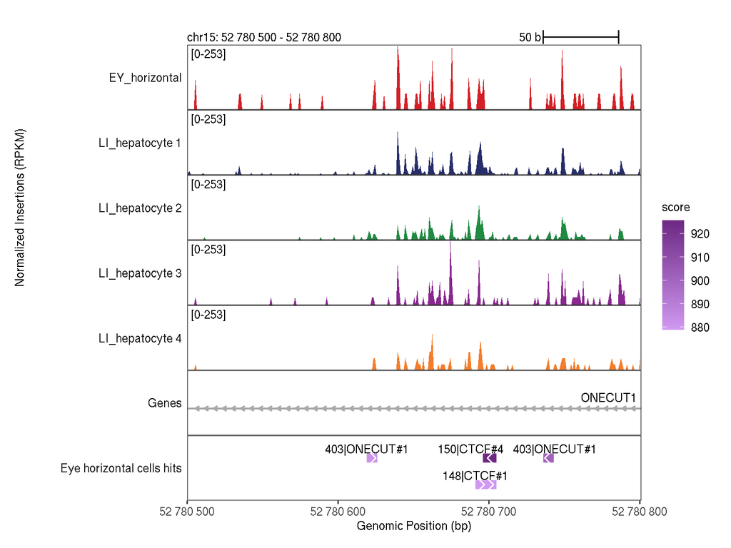

```r
submeta <- global_bp_obj$cell_metadata %>% dplyr::filter(archive_L2_clusterName %in% c("hepatocyte", "horizontal"))
p10 <- trackplot_helper_v2c(
  region="chr15:52780500-52780800",
  clusters=submeta$archive_L3_clusterID,
  fragments=global_bp_obj$frags %>% select_cells(submeta$cb),
  cell_read_counts=submeta$nFrags,
  transcripts=global_bp_obj$transcripts,
  annot=global_bp_obj$hits$Eye_c11,
  annot_color="score",
  annot_labelby="name",
  annot_strand=TRUE, # careful that if the width of the annotation is too narrow, showing strand will run into an error
  annot_label="Eye horizontal cells hits"
)
p10
```

# Example 11: ChromBPNet contribution scores add chrombpnet contribution score seqlogo annotations, around mm101 enhancer in liver

## 13.1 load chrombpnet contribution scores

Contribution score bigwigs are not stored in the global_bp_obj.rds object because they are too big. Access bigwigs on disk.

```r
cluster_meta <- global_bp_obj$cell_metadata
sub_meta <- global_bp_obj$cell_metadata %>% dplyr::filter(organ=="Liver")
sub_meta$archive_L2_clusterName <- factor(sub_meta$archive_L2_clusterName, levels=c( "erythroblast", "cycling erythroblast", "early erythroblast", "Kupffer", "B cell progenitor", "cholangiocyte", "endothelial", "hepatocyte", "megakaryocyte", "stellate"))

region <- "chr16:105080-105200" # zoomed in mm101
track_contribs_list <- list()
for (L2_cluster in levels(sub_meta$archive_L2_clusterName)){
  print(L2_cluster)
  L1_clusters <- sub_meta[sub_meta$archive_L2_clusterName==L2_cluster, "Cluster_chrombpnet"] %>% unique
  bw_contrib_list <- list()
  for (clust in L1_clusters){
    # load contribution scores
    print(paste0("loading contrib scores from ", clust))
    bw_contrib_list[[clust]] <- rtracklayer::import.bw(glue(here::here("output/03-chrombpnet/01-models/contribs/bias_Heart_c0_thresh0.4/{clust}/average_shaps.counts.bw")), selection=BigWigSelection(GRanges(region))) %>% as.data.frame
  }
  tmp <- do.call(rbind, bw_contrib_list)
  bw_contrib <- tmp %>% dplyr::group_by(seqnames,start,end, width, strand) %>% dplyr::summarise(score=mean(score)) %>% GRanges

  track_contribs_list[[L2_cluster]] <- trackplot_contribs_BL(bw_contrib,
                                       region = region,
                                       track_label = NULL,
                                       facet_label = L2_cluster,
                                       genome = BSgenome.Hsapiens.UCSC.hg38,
                                       rel_height = 1,
                                       ymax = 0.25, ymin=-0.039,
                                       ) + xlab(NULL)
}
```

```
## [1] "erythroblast"
## [1] "loading contrib scores from Liver_c2"
## [1] "loading contrib scores from Liver_c8"
```

```
## can override using the `.groups` argument.
## @ plotting basepair-level contribs for width 121
## the existing scale.
```

```
## [1] "cycling erythroblast"
## [1] "loading contrib scores from Liver_c0"
```

```
## can override using the `.groups` argument.
## @ plotting basepair-level contribs for width 121
## the existing scale.
```

```
## [1] "early erythroblast"
## [1] "loading contrib scores from Liver_c5"
```

```
## can override using the `.groups` argument.
## @ plotting basepair-level contribs for width 121
## the existing scale.
```

```
## [1] "Kupffer"
## [1] "loading contrib scores from Liver_c7"
```

```
## can override using the `.groups` argument.
## @ plotting basepair-level contribs for width 121
## the existing scale.
```

```
## [1] "B cell progenitor"
## [1] "loading contrib scores from Liver_c11"
```

```
## can override using the `.groups` argument.
## @ plotting basepair-level contribs for width 121
## the existing scale.
```

```
## [1] "cholangiocyte"
## [1] "loading contrib scores from Liver_c13"
```

```
## can override using the `.groups` argument.
## @ plotting basepair-level contribs for width 121
## the existing scale.
```

```
## [1] "endothelial"
## [1] "loading contrib scores from Liver_c10"
```

```
## can override using the `.groups` argument.
## @ plotting basepair-level contribs for width 121
## the existing scale.
```

```
## [1] "hepatocyte"
## [1] "loading contrib scores from Liver_c1"
## [1] "loading contrib scores from Liver_c3"
## [1] "loading contrib scores from Liver_c4"
## [1] "loading contrib scores from Liver_c6"
```

```
## can override using the `.groups` argument.
## @ plotting basepair-level contribs for width 121
## the existing scale.
```

```
## [1] "megakaryocyte"
## [1] "loading contrib scores from Liver_c12"
```

```
## can override using the `.groups` argument.
## @ plotting basepair-level contribs for width 121
## the existing scale.
```

```
## [1] "stellate"
## [1] "loading contrib scores from Liver_c9"
```

```
## can override using the `.groups` argument.
## @ plotting basepair-level contribs for width 121
## the existing scale.
```

## 13.2 plot tracks

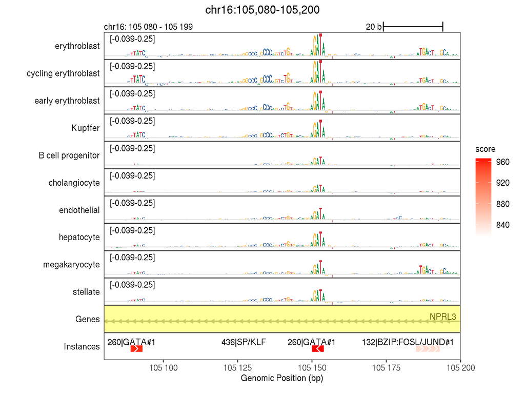

```r
region <- "chr16:105080-105200" # zoomed in mm101
track_genes <- trackplot_gene(global_bp_obj$transcripts, region) + ggplot2::guides(color = "none")
scale_plot <- trackplot_scalebar(region)
track_hits <- trackplot_genome_annotation(loci = global_bp_obj$hits[["Liver_c0"]],
                            region = region,
                            color_by = "score",
                            show_strand = T,
                            colors = c("white", "red"),
                            label_size = 3,
                            label_by = "name",
                            track_label = "Instances")
plot_list <- list(track_genes + highlight_region(region, alpha = 0.4, color = "yellow"), track_hits)
p <- trackplot_combine(c(list(scale_plot), track_contribs_list, plot_list),
                  title = str_to_pretty(region)) &
  ggplot2::theme(legend.direction = "vertical")
p
```

```r
# ggsave(plot=p, paste0(figout, "contrib_scores_mm101.pdf"), width=8, height=6)
```